# ch8.rmd

Brea Koenes

10/24/2022

# Chapter 8

## 8.14

Beta-Binomial is the correct choice in model because the prior is binomial. Specifically, the subject either believes in climate change or does not.

My prior understanding is that, on average, less people will not believe in climate change. In other words, I think that more people believe that climate change is real than the authors think.

```r
summary(pulse_of_the_nation)
```

```
##      income            age                party
##  Min.   :  5.00   Min.   :18.00   Democrat   :327
##  1st Qu.: 55.00   1st Qu.:37.00   Independent:425
##  Median : 80.00   Median :50.00   Republican :248
##  Mean   : 90.47   Mean   :49.41
##  3rd Qu.:114.00   3rd Qu.:61.00
##  Max.   :500.00   Max.   :99.00
##                         trump_approval           education        robots
##  Neither approve nor disapprove: 58    College degree :313   Likely  :199
##  Somewhat Approve              :139    Graduate degree:203   Unlikely:801
##  Somewhat disapprove           : 92    High school    :191
##  Strongly Approve              :251    Other          : 18
##  Strongly disapprove           :460    Some college   :275
##
##                        climate_change  transformers
##  Not Real At All              :150    Min.   :0.000
##  Real and Caused by People    :655    1st Qu.:0.000
##  Real but not Caused by People:195    Median :1.000
##                                       Mean   :1.323
##                                       3rd Qu.:2.000
##                                       Max.   :5.000
##                   science_is_honest                  vaccines_are_safe
##  Neither Agree nor Disagree: 19     Neither Agree nor Disagree: 16
##  Somewhat Agree            :353     Somewhat Agree            :206
##  Somewhat Disagree         :144     Somewhat Disagree         : 76
##  Strongly Agree            :377     Strongly Agree            :642
##  Strongly Disagree         :107     Strongly Disagree         : 60
##
##      books         ghosts        fed_sci_budget earth_sun
##  Min.   :   0.00   No :621   About Right:345    Mode :logical
##  1st Qu.:   2.00   Yes:379   Too High   :155    FALSE:449
##  Median :   5.00             Too Low    :500    TRUE :551
##  Mean   :  22.01
##  3rd Qu.:  17.00
##  Max.   :1000.00
##            wise_unwise
##  Happy but Unwise:522
##  Wise but Unhappy:478
##
##
##
##
```

150/1000= 15% don’t believe it’s real at all

```r
summarize_beta_binomial(alpha = 1, beta = 2, y = 150, n = 1000)
```

```
##       model alpha beta      mean      mode          var         sd
## 1     prior     1    2 0.3333333 0.0000000 0.0555555556 0.23570226
## 2 posterior   151  852 0.1505484 0.1498501 0.0001273741 0.01128601
```

```r
qbeta(c(0.25, 0.975), 151, 852)
```

```
## [1] 0.1428100 0.1733164
```

## 8.15

Given the credible interval above, it is likely that the true proportion lies within 14-17%. The null hypothesis states that the proportion is equal to or lower than 10%. The alternative hypothesis is that the proportion is greater than 10%. With this information, I would personally raise the null hypothesis to be equal to or lower than 0.14, and the laternative hypothesis greater than 0.14.

```r
prior_prob <- pbeta(0.10, 1, 2)
prior_odds <- prior_prob / (1 - prior_prob)

post_prob <- 1-prior_prob
post_prob
```

```
## [1] 0.81
```

```r
post_odds <- post_prob / (1 - post_prob)
post_odds
```

```
## [1] 4.263158
```

```r
BF <- post_odds / prior_odds
BF
```

```
## [1] 18.17452
```

The posterior odds of our hypothesis are roughly 18 times higher than the prior odds

Our alternative hypothesis that pi is greater than 10% is quite likely to occur. In the context of our scenario, it is very likely the true proportion of people that don’t believe in climate change is over 10%.

## 8.16

```r
climate_model <- "
  data {
    int<lower = 0, upper = 1000> Y;
  }
  parameters {
    real<lower = 0, upper = 1> pi;
  }
  model {
    Y ~ binomial(150, pi);
    pi ~ beta(1,2);
  }
"

# STEP 2: SIMULATE the posterior
sim <- stan(model_code = climate_model,
             data = list(Y = 150),
             chains = 4,
             iter = 5000*2,
             seed = 84735)
```

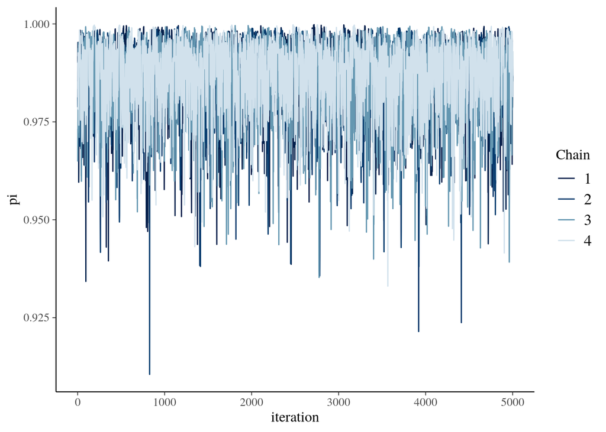

```r
require(bayesplot)

# Parallel trace plots & density plots
mcmc_trace(sim, pars = "pi", size = .5) +
  xlab("iteration")
```

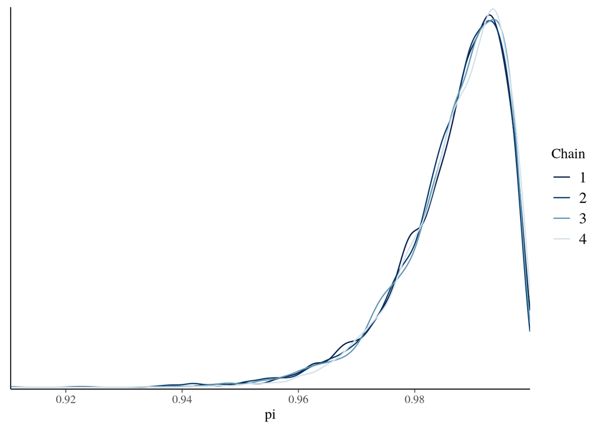

```r
mcmc_dens_overlay(sim, pars = "pi")
```

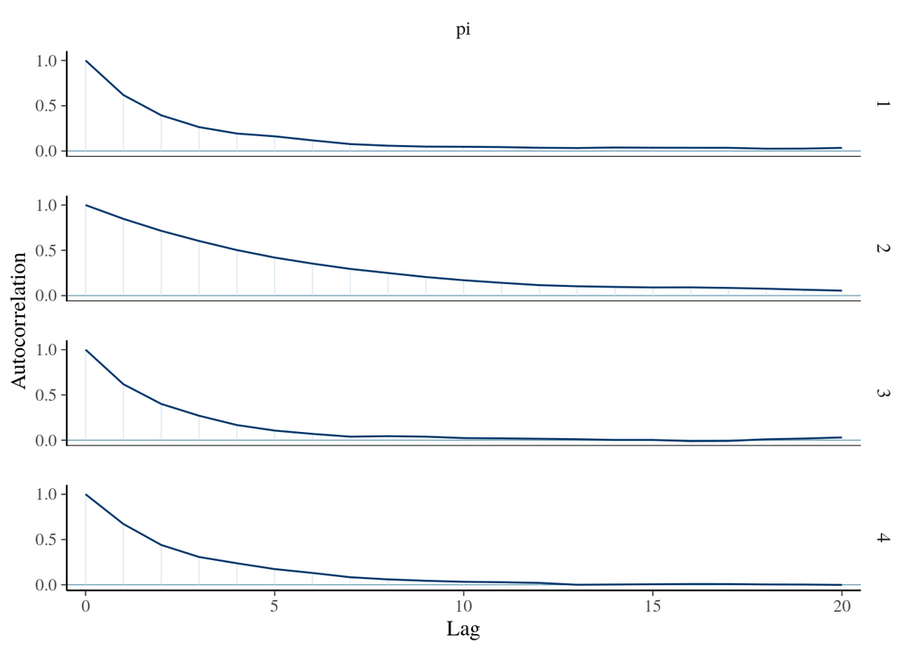

```r
# Autocorrelation plot
mcmc_acf(sim, pars = "pi")
```

```r
neff_ratio(sim, pars = "pi")
```

```
## [1] 0.1392111
```

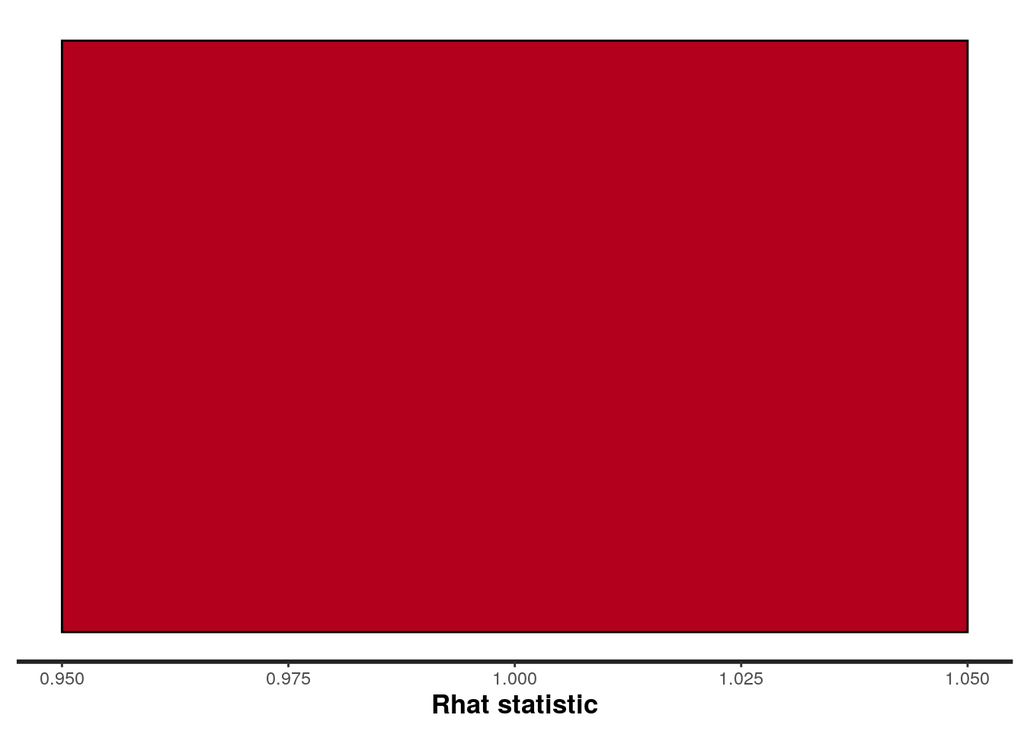

```r
stan_rhat(sim, par = "pi")
```

```r
summary(sim)
```

```
## $summary
##             mean      se_mean          sd        2.5%         25%       50%
## pi     0.9869215 0.0001730642 0.009131856   0.9636399   0.9824626   0.98896
## lp__ -11.1938866 0.0143207213 0.742510251 -13.3555863 -11.3616709 -10.90967
##              75%       97.5%    n_eff     Rhat
## pi     0.9936319   0.9983642 2784.222 1.000833
## lp__ -10.7155887 -10.6620034 2688.284 1.000666
##
## $c_summary
## , , chains = chain:1
##
##          stats
## parameter        mean          sd        2.5%         25%         50%
##      pi     0.9868422 0.009102389   0.9634296   0.9822753   0.9889105
##      lp__ -11.1977602 0.751874149 -13.4140799 -11.3600374 -10.9099233
##          stats
## parameter         75%       97.5%
##      pi     0.9935054   0.9985156
##      lp__ -10.7160458 -10.6620492
##
## , , chains = chain:2
##
##          stats
## parameter        mean          sd        2.5%         25%         50%
##      pi     0.9865557 0.009516495   0.9624541   0.9823085   0.9887347
##      lp__ -11.1693471 0.700662371 -13.1739077 -11.3449980 -10.8959421
##          stats
## parameter         75%       97.5%
##      pi     0.9933832   0.9980593
##      lp__ -10.7123189 -10.6622391
##
## , , chains = chain:3
##
##          stats
## parameter        mean          sd        2.5%         25%         50%
##      pi     0.9868753 0.009166595   0.9630641   0.9824877   0.9890113
##      lp__ -11.1814987 0.693838235 -13.1490309 -11.3596654 -10.9075170
##          stats
## parameter         75%     97.5%
##      pi     0.9936755   0.99811
##      lp__ -10.7158527 -10.66189
##
## , , chains = chain:4
##
##          stats
## parameter        mean          sd        2.5%         25%        50%
##      pi     0.9874128 0.008705514   0.9660821   0.9828689   0.989223
##      lp__ -11.2269404 0.816148996 -13.7114757 -11.3870637 -10.921609
##          stats
## parameter         75%       97.5%
##      pi     0.9939681   0.9987931
##      lp__ -10.7187437 -10.6619608
```

R-hat is a convergence diagnostic; it tells us whether or not an MCMC algorithm has converged flag situations where the algorithm has failed converge. Effective sample size tells us the effectiveness of a sample chain; it estimates the sample size required to achieve the same level of precision if the pulse of the sample used was a simple random sample.

## 8.17

```r
tidy(sim, conf.int = TRUE, conf.level = 0.95)
```

```
## # A tibble: 1 × 5
##   term  estimate std.error conf.low conf.high
##   <chr>    <dbl>     <dbl>    <dbl>     <dbl>
## 1 pi       0.989   0.00913    0.964     0.998
```

```r
chains_df <- as.data.frame(sim, pars = "lp__", include = FALSE)
```

```r
chains_df |>
  mutate(exceeds = pi > 0.1) |>
  tabyl(exceeds)
```

```
##  exceeds     n percent
##     TRUE 20000       1
```

## 8.18

```r
set.seed(1)

# Predict a value of Y' for each pi value in the chain
chains_df <- chains_df |>
  mutate(y_predict = rbinom(length(pi), size = 100, prob = pi))
```

```r
summary(chains_df)
```

```
##        pi           y_predict
##  Min.   :0.9105   Min.   : 89.00
##  1st Qu.:0.9825   1st Qu.: 98.00
##  Median :0.9890   Median : 99.00
##  Mean   :0.9869   Mean   : 98.69
##  3rd Qu.:0.9936   3rd Qu.:100.00
##  Max.   :0.9998   Max.   :100.00
```

```r
chains_df |>
  summarize(mean = mean(y_predict),
            lower_20 = quantile(y_predict, 0.2),
            upper_20 = quantile(y_predict, 0.8))
```

```
##      mean lower_20 upper_20
## 1 98.6896       98      100
```

## 8.21

```r
glimpse(loons)
```

```
## Rows: 18
## Columns: 5
## $ year           <dbl> 2000, 2001, 2002, 2003, 2004, 2005, 2006, 2007, 2008, 2…
## $ count          <dbl> 0, 7, 0, 1, 1, 4, 1, 4, 2, 2, 0, 9, 3, 0, 5, 7, 2, 5
## $ hours          <dbl> 143.50, 153.50, 228.30, 248.75, 203.75, 245.75, 223.00,…
## $ count_per_hour <dbl> 0.000000000, 0.045602606, 0.000000000, 0.004020101, 0.0…
## $ count_per_100  <dbl> 0, 5, 0, 0, 0, 2, 0, 2, 1, 1, 0, 4, 2, 0, 3, 3, 1, 3
```

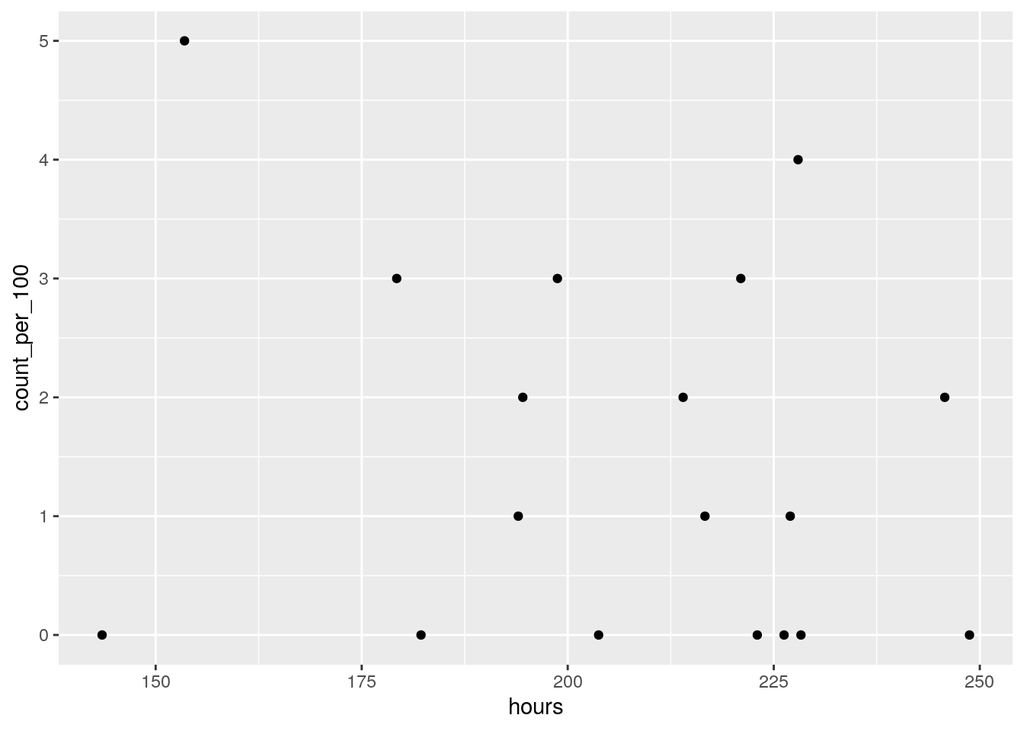

```r
gf_point(count_per_100~hours, data=loons)
```

Looking at the distribution of data, I would choose a Gamma-Poisson model. The Poisson model won’t predict negative values and the shape of its distribution changes.

```r
summary(loons)
```

```
##       year          count           hours       count_per_hour
##  Min.   :2000   Min.   :0.000   Min.   :143.5   Min.   :0.000000
##  1st Qu.:2004   1st Qu.:1.000   1st Qu.:194.1   1st Qu.:0.004136
##  Median :2008   Median :2.000   Median :215.3   Median :0.009770
##  Mean   :2008   Mean   :2.944   Mean   :207.1   Mean   :0.014553
##  3rd Qu.:2013   3rd Qu.:4.750   3rd Qu.:226.8   3rd Qu.:0.023541
##  Max.   :2017   Max.   :9.000   Max.   :248.8   Max.   :0.045603
##  count_per_100
##  Min.   :0.00
##  1st Qu.:0.00
##  Median :1.00
##  Mean   :1.50
##  3rd Qu.:2.75
##  Max.   :5.00
```

```r
loons
```

```
## # A tibble: 18 × 5
##     year count hours count_per_hour count_per_100
##    <dbl> <dbl> <dbl>          <dbl>         <dbl>
##  1  2000     0  144.        0                   0
##  2  2001     7  154.        0.0456              5
##  3  2002     0  228.        0                   0
##  4  2003     1  249.        0.00402             0
##  5  2004     1  204.        0.00491             0
##  6  2005     4  246.        0.0163              2
##  7  2006     1  223         0.00448             0
##  8  2007     4  214         0.0187              2
##  9  2008     2  227         0.00881             1
## 10  2009     2  194         0.0103              1
## 11  2010     0  226.        0                   0
## 12  2011     9  228.        0.0395              4
## 13  2012     3  195.        0.0154              2
## 14  2013     0  182.        0                   0
## 15  2014     5  179.        0.0279              3
## 16  2015     7  221         0.0317              3
## 17  2016     2  217.        0.00923             1
## 18  2017     5  199.        0.0252              3
```

The mean count per 100 is 1.5. There are observations of count_per_100, including 0’s.

```r
summarize_gamma_poisson(shape = 2, rate = 1, sum_y = 1.5, n = 3)
```

```
##       model shape rate  mean  mode     var        sd
## 1     prior   2.0    1 2.000 1.000 2.00000 1.4142136
## 2 posterior   3.5    4 0.875 0.625 0.21875 0.4677072
```

```r
qbeta(c(0.25, 0.975), 3.5, 4)
```

```
## [1] 0.3402192 0.7984883
```

## 8.22

$$H_0 = \lambda >= 0.01 \\
H_a = \lambda >= 0.01$$

```r
post_prob <- pbeta(0.01, 2, 1)
post_prob
```

```
## [1] 1e-04
```

My conclusion about lambda is that the null hypothesis is much more likely than the alternative hypothesis. This means that the true proportion of loon sightings in a 100-hour observation period is likely to be greater than 1%.

## 8.23

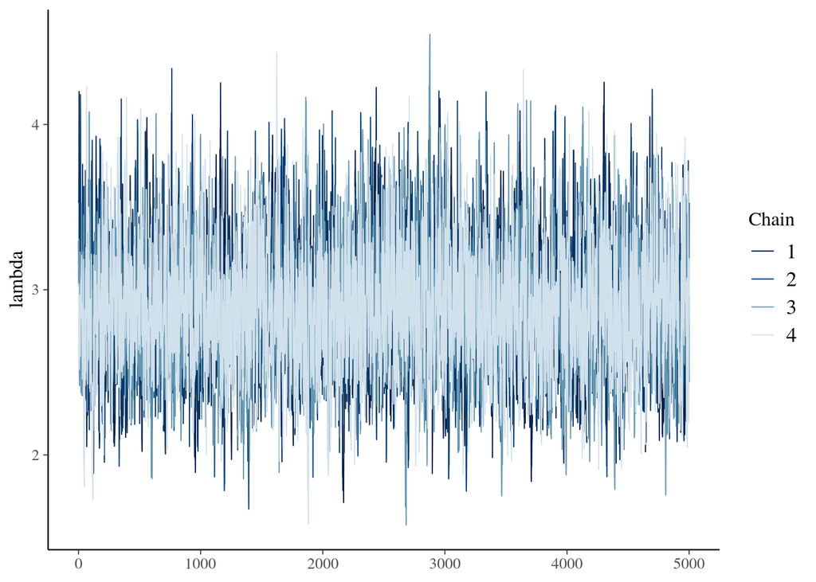

```r
# Define model
loon_model <- "
  data {
    int<lower = 0> n;
    int<lower = 0> Y[n];
  }
  parameters {
    real<lower = 0> lambda;
  }
  model {
    Y ~ poisson(lambda);
    lambda ~ gamma(2, 1);
  }
"

# Simulate the posterior
loon_sim <- stan(model_code = loon_model, data = list(Y = loons$count, n = nrow(loons)),
               chains = 4, iter = (5000*2), seed = 84735)
mcmc_trace(loon_sim, pars = "lambda")
```

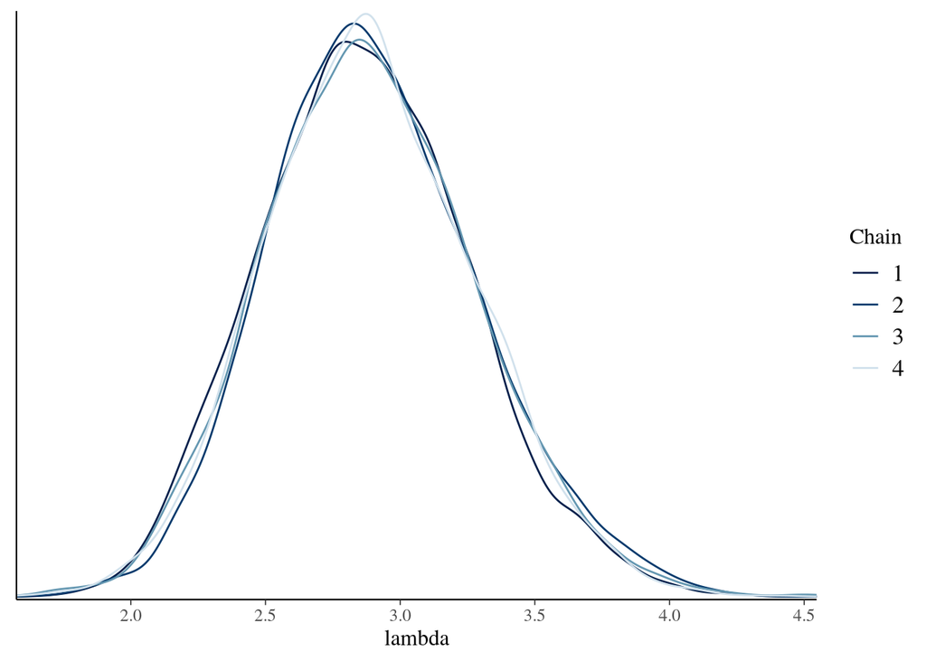

```r
mcmc_dens_overlay(loon_sim, pars = "lambda")
```

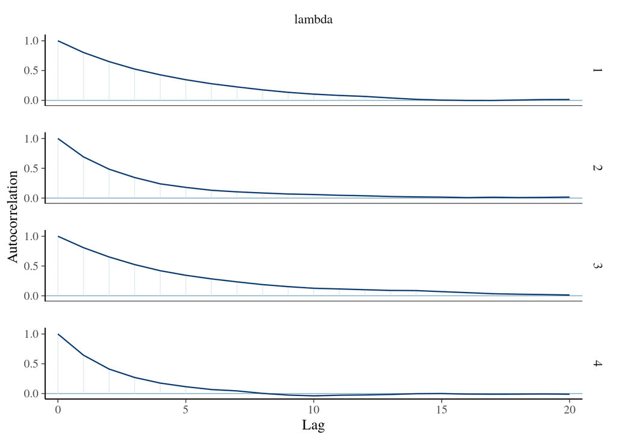

```r
mcmc_acf(loon_sim, pars = "lambda")
```

```r
neff_ratio(loon_sim, pars = "lambda")
```

```
## [1] 0.1358625
```

```r
tidy(loon_sim, conf.int = TRUE, conf.level = 0.95)
```

```
## # A tibble: 1 × 5
##   term   estimate std.error conf.low conf.high
##   <chr>     <dbl>     <dbl>    <dbl>     <dbl>
## 1 lambda     2.87     0.390     2.17      3.70
```

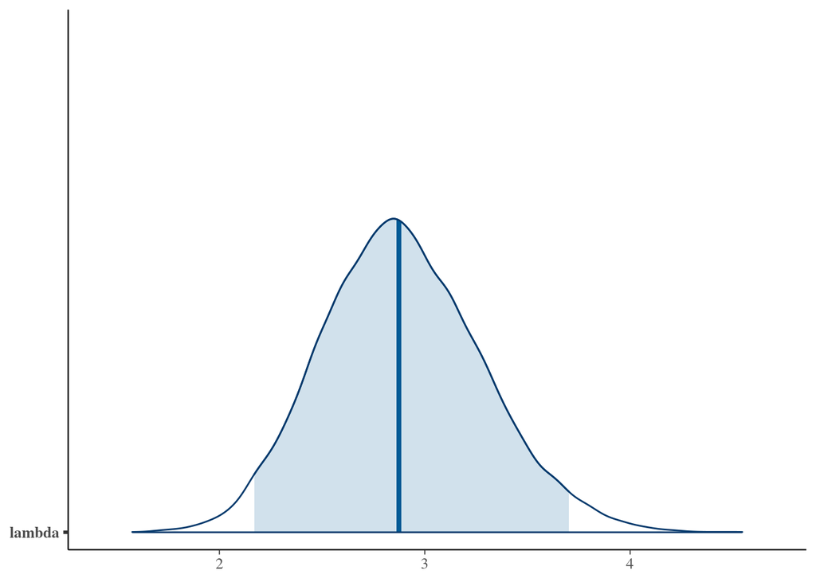

```r
mcmc_areas(loon_sim, pars = "lambda", prob = 0.95)
```

```r
loon_chains_df <- as.data.frame(loon_sim, pars = "lp__", include = FALSE)

loon_chains_df |>
  mutate(exceeds = lambda < 1) |>
  tabyl(exceeds)
```

```
##  exceeds     n percent
##    FALSE 20000       1
```

## 8.24

```r
set.seed(1)

loon_chains_df <- loon_chains_df |>
  mutate(y_predict = rgamma(shape = 2, length(lambda)))

loon_chains_df |>
  head(3)
```

```
##     lambda y_predict
## 1 3.539372  0.830865
## 2 3.527464  3.570756
## 3 3.567871  3.463170
```

[figure not shown]

```r
ggplot(loon_chains_df, aes(x = y_predict)) +
  stat_count()
```

```r
loon_chains_df |>
  summarize(mean = mean(y_predict),
            lower_80 = quantile(y_predict, 0.1),
            upper_80 = quantile(y_predict, 0.9))
```

```
##       mean  lower_80 upper_80
## 1 2.018865 0.5346671  3.93675
```

```r
loon_chains_df <- as.data.frame(loon_sim, pars = "lp__", include = FALSE)

loon_chains_df |>
  mutate(zero = lambda == 0) |>
  tabyl(zero)
```

```
##   zero     n percent
##  FALSE 20000       1
```